# Modelling with Support Vector Machine (SVM) Algorithms via the Caret Pipeline

Hieu Nguyen

This is an R-Markdown Notebook create a sequence or pipeline of data transformations and machine learning operations using the caret package. The pipeline will develop a model to classify Breast-Cancer cases using Support Vector Machine Algorithms.

By creating a Caret pipeline, you can streamline and automate these steps, making it easier to experiment with different algorithms and configurations while ensuring consistent preprocessing and evaluation procedures. This facilitates efficient and reproducible machine learning workflows in R.

## Data

We shall now load the data and summarise it

```r
data <- read.csv(file = "breast-cancer.csv", stringsAsFactors = TRUE)
str(data)
```

```
## 'data.frame':    569 obs. of  32 variables:
##  $ id                     : int  842302 842517 84300903 84348301 84358402 843786 844359 84458202 844981 84501001 ...
##  $ diagnosis              : Factor w/ 2 levels "B","M": 2 2 2 2 2 2 2 2 2 2 ...
##  $ radius_mean            : num  18 20.6 19.7 11.4 20.3 ...
##  $ texture_mean           : num  10.4 17.8 21.2 20.4 14.3 ...
##  $ perimeter_mean         : num  122.8 132.9 130 77.6 135.1 ...
##  $ area_mean              : num  1001 1326 1203 386 1297 ...
##  $ smoothness_mean        : num  0.1184 0.0847 0.1096 0.1425 0.1003 ...
##  $ compactness_mean       : num  0.2776 0.0786 0.1599 0.2839 0.1328 ...
##  $ concavity_mean         : num  0.3001 0.0869 0.1974 0.2414 0.198 ...
##  $ concave.points_mean    : num  0.1471 0.0702 0.1279 0.1052 0.1043 ...
##  $ symmetry_mean          : num  0.242 0.181 0.207 0.26 0.181 ...
##  $ fractal_dimension_mean : num  0.0787 0.0567 0.06 0.0974 0.0588 ...
##  $ radius_se              : num  1.095 0.543 0.746 0.496 0.757 ...
##  $ texture_se             : num  0.905 0.734 0.787 1.156 0.781 ...
```

[output cut: 18 more lines]

## Test/train

We need to separate test from train as early as possible

```r
index <- caret::createDataPartition(y = data$diagnosis, p = 0.7, list = FALSE)
train <- data[index, ]
test <- data[-index, ]
```

## Preprocessing

The recipe will be as follows:

- diagnosis is the target
- id is the identifier
- up-sample the minority class
- normalise the numeric predictors
- experiment with dimensional reduction to 5 components

```r
recipe5 <- recipe(diagnosis ~., data = train) %>%
  update_role(id, new_role = "id") %>%
  step_bsmote(diagnosis) %>%
  step_normalize(all_numeric_predictors()) %>%
  step_umap(all_numeric_predictors(), outcome = "diagnosis", num_comp = 5)
```

## Modeling (SVM)

This preprocessing can be used with an SVMRadial method

```r
trainCont <- trainControl(method = "cv", number = 10, summaryFunction = twoClassSummary, classProbs = TRUE)
model_svmRad5 <- recipe5 %>%
  train(data = train, method = "svmRadial", trControl = trainCont, metric = "ROC")
model_svmRad5
```

```
## Support Vector Machines with Radial Basis Function Kernel
##
## 399 samples
##  31 predictor
##   2 classes: 'B', 'M'
##
## Recipe steps: bsmote, normalize, umap
## Resampling: Cross-Validated (10 fold)
## Summary of sample sizes: 359, 359, 360, 359, 359, 359, ...
## Resampling results across tuning parameters:
##
##   C     ROC        Sens   Spec
##   0.25  0.9674095  0.916  0.9395238
##   0.50  0.9634095  0.916  0.9395238
##   1.00  0.9623429  0.916  0.9395238
##
## Tuning parameter 'sigma' was held constant at a value of 7.274962
## ROC was used to select the optimal model using the largest value.
## The final values used for the model were sigma = 7.274962 and C = 0.25.
```

## Assessment

What does this mean for unseen data?

```r
results <- predict(model_svmRad5, newdata = test)
actual <- test$diagnosis
caret::confusionMatrix(results, actual)
```

```
## Confusion Matrix and Statistics
##
##           Reference
## Prediction   B   M
##          B 103   1
##          M   4  62
##
##                Accuracy : 0.9706
##                  95% CI : (0.9327, 0.9904)
##     No Information Rate : 0.6294
##     P-Value [Acc > NIR] : <2e-16
##
##                   Kappa : 0.9376
##
##  Mcnemar's Test P-Value : 0.3711
##
##             Sensitivity : 0.9626
##             Specificity : 0.9841
##          Pos Pred Value : 0.9904
##          Neg Pred Value : 0.9394
##              Prevalence : 0.6294
##          Detection Rate : 0.6059
##    Detection Prevalence : 0.6118
##       Balanced Accuracy : 0.9734
##
##        'Positive' Class : B
##
```

## Repeat for 10 components

Let’s try this for `num_comp = 10`

```r
recipe10 <- recipe(diagnosis ~., data = train) %>%
  update_role(id, new_role = "id") %>%
  step_bsmote(diagnosis) %>%
  step_normalize(all_numeric_predictors()) %>%
  step_umap(all_numeric_predictors(), outcome = "diagnosis", num_comp = 10)
model_svmRad10 <- recipe10 %>%
  train(data = train, method = "svmRadial", trControl = trainCont, metric = "ROC")
results <- predict(model_svmRad10, newdata = test)
actual <- test$diagnosis
caret::confusionMatrix(results, actual)
```

```
## Confusion Matrix and Statistics
##
##           Reference
## Prediction   B   M
##          B 103   1
##          M   4  62
##
##                Accuracy : 0.9706
##                  95% CI : (0.9327, 0.9904)
##     No Information Rate : 0.6294
##     P-Value [Acc > NIR] : <2e-16
##
##                   Kappa : 0.9376
##
##  Mcnemar's Test P-Value : 0.3711
##
##             Sensitivity : 0.9626
##             Specificity : 0.9841
##          Pos Pred Value : 0.9904
##          Neg Pred Value : 0.9394
##              Prevalence : 0.6294
##          Detection Rate : 0.6059
##    Detection Prevalence : 0.6118
##       Balanced Accuracy : 0.9734
##
##        'Positive' Class : B
##
```

```r
model_svmRad10
```

```
## Support Vector Machines with Radial Basis Function Kernel
##
## 399 samples
##  31 predictor
##   2 classes: 'B', 'M'
##
## Recipe steps: bsmote, normalize, umap
## Resampling: Cross-Validated (10 fold)
## Summary of sample sizes: 359, 359, 359, 359, 359, 360, ...
## Resampling results across tuning parameters:
##
##   C     ROC        Sens   Spec
##   0.25  0.9738286  0.924  0.96
##   0.50  0.9768000  0.928  0.96
##   1.00  0.9752000  0.928  0.96
##
## Tuning parameter 'sigma' was held constant at a value of 0.6663382
## ROC was used to select the optimal model using the largest value.
## The final values used for the model were sigma = 0.6663382 and C = 0.5.
```

## Repeat for 15 components

Let’s try this for `num_comp = 15`

```r
recipe15 <- recipe(diagnosis ~., data = train) %>%
  update_role(id, new_role = "id") %>%
  step_bsmote(diagnosis) %>%
  step_normalize(all_numeric_predictors()) %>%
  step_umap(all_numeric_predictors(), outcome = "diagnosis", num_comp = 15)
model_svmRad15 <- recipe15 %>%
  train(data = train, method = "svmRadial", trControl = trainCont, metric = "ROC")
results <- predict(model_svmRad15, newdata = test)
actual <- test$diagnosis
caret::confusionMatrix(results, actual)
```

```
## Confusion Matrix and Statistics
##
##           Reference
## Prediction   B   M
##          B 103   1
##          M   4  62
##
##                Accuracy : 0.9706
##                  95% CI : (0.9327, 0.9904)
##     No Information Rate : 0.6294
##     P-Value [Acc > NIR] : <2e-16
##
##                   Kappa : 0.9376
##
##  Mcnemar's Test P-Value : 0.3711
##
##             Sensitivity : 0.9626
##             Specificity : 0.9841
##          Pos Pred Value : 0.9904
##          Neg Pred Value : 0.9394
##              Prevalence : 0.6294
##          Detection Rate : 0.6059
##    Detection Prevalence : 0.6118
##       Balanced Accuracy : 0.9734
##
##        'Positive' Class : B
##
```

## Conclusion

```r
model_svmRad10
```

```
## Support Vector Machines with Radial Basis Function Kernel
##
## 399 samples
##  31 predictor
##   2 classes: 'B', 'M'
##
## Recipe steps: bsmote, normalize, umap
## Resampling: Cross-Validated (10 fold)
## Summary of sample sizes: 359, 359, 359, 359, 359, 360, ...
## Resampling results across tuning parameters:
##
##   C     ROC        Sens   Spec
##   0.25  0.9738286  0.924  0.96
##   0.50  0.9768000  0.928  0.96
##   1.00  0.9752000  0.928  0.96
##
## Tuning parameter 'sigma' was held constant at a value of 0.6663382
## ROC was used to select the optimal model using the largest value.
## The final values used for the model were sigma = 0.6663382 and C = 0.5.
```

The “test” confusion matrix can be visualised using an alluvial plot.

```r
results <- predict(model_svmRad15, newdata = test)
actual <- test$diagnosis
cm <- caret::confusionMatrix(results, actual)
cm
```

```
## Confusion Matrix and Statistics
##
##           Reference
## Prediction   B   M
##          B 103   1
##          M   4  62
##
##                Accuracy : 0.9706
##                  95% CI : (0.9327, 0.9904)
##     No Information Rate : 0.6294
##     P-Value [Acc > NIR] : <2e-16
##
##                   Kappa : 0.9376
##
##  Mcnemar's Test P-Value : 0.3711
##
##             Sensitivity : 0.9626
##             Specificity : 0.9841
##          Pos Pred Value : 0.9904
##          Neg Pred Value : 0.9394
##              Prevalence : 0.6294
##          Detection Rate : 0.6059
##    Detection Prevalence : 0.6118
##       Balanced Accuracy : 0.9734
##
##        'Positive' Class : B
##
```

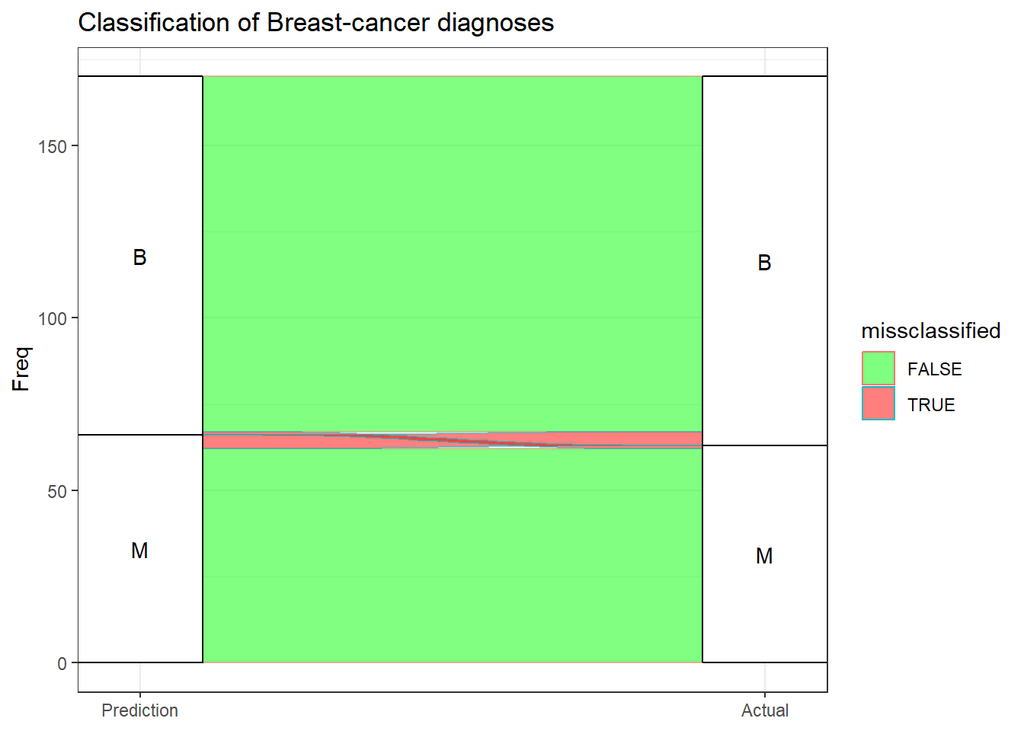

```r
data <- as.data.frame(cm$table)
data$missclassified <- data$Prediction != data$Reference
ggplot(data = data, mapping = aes(y = Freq, axis1 = Prediction, axis2 = Reference, label = after_stat(stratum))) +
  ggalluvial::geom_alluvium(aes(fill = missclassified, colour = missclassified), show.legend = TRUE) +
  ggalluvial::geom_stratum(width = 0.2) +
  geom_text(stat = "stratum", reverse = TRUE) +
  scale_x_discrete(limits = c("Prediction", "Actual"), expand = c(0.0, 0.0)) +
  ggtitle("Classification of Breast-cancer diagnoses") +
  scale_fill_manual(values = c("green","red")) +
  theme_bw()
```